# Practica2

Sebastian Cueva, Pol Gracia

11/12/2022

# 0. Imports

A continuación se expone el código y comentarios resultados de la realización de la práctica 2. #### Importar librerias

```r
library(tidyverse)
library(tidyr)
library(dplyr)
library(knitr)
library(ggplot2)
library(stringr)
library(reshape)
library(minerva)
library(heatmaply)
library(kableExtra)
library(factoextra)
library(ggbiplot)
library(randomForest)
library(ROCR)
library(vcd)
library(ggmosaic)
library(cowplot)
library(caret)
library(e1071)
library(caTools)
library(class)
library(AUC)
library(ggcorrplot)
```

#### Importar datos

Aunque se nos entrega el fichero de train entero y podriamos obtener la variable respuesta, se trataran cómo si de un caso real se tratara, y todo el EDA y el training se usara solo el p2_train. El p2_test se usara únicamente para validar los resultados al final de todo de la practica.

```r
p2_train <- read.csv("D:/Master big data/Estadistica/Practica 1/P2-BANK-STUDENTS (1)/P2-BANK-STUDENTS/p2_train.csv", head = TRUE, sep=";", stringsAsFactors=TRUE)

p2_test <- read.csv("D:/Master big data/Estadistica/Practica 1/P2-BANK-STUDENTS (1)/P2-BANK-STUDENTS/p2_test.csv", sep=";", head = TRUE, stringsAsFactors=TRUE)
p2_test_fin <- read.csv("D:/Master big data/Estadistica/Practica 1/P2-BANK-STUDENTS (1)/P2-BANK-STUDENTS/p2_test.csv", sep=";", head = TRUE, stringsAsFactors=TRUE)
```

# 1. Preprocesado de los datos

En este apartado se va hacer el análisi exploratorio de los datos.

```r
head(p2_train)
```

|  | id | age | job | marital | education | default | housing | loan | contact | month | day_of_week | campaign | pdays | previous | poutcome | emp.var.rate | cons.price.idx | cons.conf.idx | euribor3m | nr.employed | y |
| --- | --- | --- | --- | --- | --- | --- | --- | --- | --- | --- | --- | --- | --- | --- | --- | --- | --- | --- | --- | --- | --- |
| 1 | 1 | 52 | technician | married | high.school | no | yes | no | cellular | nov | tue | 1 | 999 | 0 | nonexistent | -0.1 | 93.200 | -42.0 | 4.153 | 5195.8 | no |
| 2 | 2 | 33 | admin. | single | university.degree | no | yes | no | cellular | nov | thu | 1 | 999 | 0 | nonexistent | -0.1 | 93.200 | -42.0 | 4.076 | 5195.8 | no |
| 3 | 5 | 54 | admin. | single | university.degree | no | yes | no | cellular | may | mon | 1 | 999 | 0 | nonexistent | -1.8 | 92.893 | -46.2 | 1.264 | 5099.1 | no |
| 4 | 6 | 53 | housemaid | married | high.school | no | no | yes | cellular | jun | thu | 1 | 999 | 2 | failure | -2.9 | 92.963 | -40.8 | 1.260 | 5076.2 | yes |
| 5 | 8 | 42 | self-employed | married | university.degree | unknown | yes | no | cellular | aug | tue | 2 | 999 | 0 | nonexistent | 1.4 | 93.444 | -36.1 | 4.966 | 5228.1 | no |
| 6 | 10 | 36 | management | married | university.degree | no | no | yes | cellular | jul | wed | 4 | 999 | 0 | nonexistent | 1.4 | 93.918 | -42.7 | 4.963 | 5228.1 | no |

Summary de los datos

```r
summary(p2_train)
```

```
       id             age                 job           marital                    education       default         housing
 Min.   :    1   Min.   :17.00   admin.     :7213   divorced: 3190   university.degree  :8431   no     :22691   no     :12928
 1st Qu.:10354   1st Qu.:32.00   blue-collar:6459   married :17361   high.school        :6692   unknown: 5952   unknown:  704
 Median :20547   Median :38.00   technician :4700   single  : 8038   basic.9y           :4191   yes    :    2   yes    :15013
 Mean   :20605   Mean   :39.98   services   :2718   unknown :   56   professional.course:3610
 3rd Qu.:30921   3rd Qu.:47.00   management :2082                    basic.4y           :2866
 Max.   :41187   Max.   :98.00   retired    :1202                    basic.6y           :1631
                                 (Other)    :4271                    (Other)            :1224
      loan            contact          month      day_of_week    campaign          pdays          previous
 no     :23613   cellular :18190   may    :9552   fri:5401    Min.   : 1.000   Min.   :  0.0   Min.   :0.0000
 unknown:  704   telephone:10455   jul    :5060   mon:5885    1st Qu.: 1.000   1st Qu.:999.0   1st Qu.:0.0000
 yes    : 4328                     aug    :4287   thu:6061    Median : 2.000   Median :999.0   Median :0.0000
                                   jun    :3670   tue:5608    Mean   : 2.559   Mean   :962.6   Mean   :0.1685
                                   nov    :2845   wed:5690    3rd Qu.: 3.000   3rd Qu.:999.0   3rd Qu.:0.0000
                                   apr    :1822               Max.   :43.000   Max.   :999.0   Max.   :7.0000
                                   (Other):1409
        poutcome      emp.var.rate      cons.price.idx  cons.conf.idx      euribor3m      nr.employed     y
 failure    : 2870   Min.   :-3.40000   Min.   :92.20   Min.   :-50.80   Min.   :0.634   Min.   :4964   no :25362
 nonexistent:24824   1st Qu.:-1.80000   1st Qu.:93.08   1st Qu.:-42.70   1st Qu.:1.344   1st Qu.:5099   yes: 3283
 success    :  951   Median : 1.10000   Median :93.80   Median :-41.80   Median :4.857   Median :5191
                     Mean   : 0.08153   Mean   :93.58   Mean   :-40.48   Mean   :3.622   Mean   :5167
                     3rd Qu.: 1.40000   3rd Qu.:93.99   3rd Qu.:-36.40   3rd Qu.:4.961   3rd Qu.:5228
                     Max.   : 1.40000   Max.   :94.77   Max.   :-26.90   Max.   :5.045   Max.   :5228
```

```r
p2_train <- p2_train %>% select(-pdays)
```

### Para los datos :

#### 1.0 Nan handling

Se puede apreciar que no encontramos ningún nan en las columnas del dataset, haciendo que no tengamos que tratar con ellos.

```r
p2_train %>% group_by() %>% summarise_all(funs(sum(is.na(.))))
```

| id | age | job | marital | education | default | housing | loan | contact | month | day_of_week | campaign | previous | poutcome | emp.var.rate | cons.price.idx | cons.conf.idx | euribor3m | nr.employed | y |
| --- | --- | --- | --- | --- | --- | --- | --- | --- | --- | --- | --- | --- | --- | --- | --- | --- | --- | --- | --- |
| 0 | 0 | 0 | 0 | 0 | 0 | 0 | 0 | 0 | 0 | 0 | 0 | 0 | 0 | 0 | 0 | 0 | 0 | 0 | 0 |

#### 1.1 Duplicates handling

Se eliminan las filas duplicadas del dataset.

```r
p2_train <- p2_train %>%
                distinct()
p2_train
```

| id | age | job | marital | education | default | housing | loan | contact | month | day_of_week | campaign | previous | poutcome | emp.var.rate | cons.price.idx | cons.conf.idx | euribor3m | nr.employed | y |
| --- | --- | --- | --- | --- | --- | --- | --- | --- | --- | --- | --- | --- | --- | --- | --- | --- | --- | --- | --- |
| 1 | 52 | technician | married | high.school | no | yes | no | cellular | nov | tue | 1 | 0 | nonexistent | -0.1 | 93.200 | -42.0 | 4.153 | 5195.8 | no |
| 2 | 33 | admin. | single | university.degree | no | yes | no | cellular | nov | thu | 1 | 0 | nonexistent | -0.1 | 93.200 | -42.0 | 4.076 | 5195.8 | no |
| 5 | 54 | admin. | single | university.degree | no | yes | no | cellular | may | mon | 1 | 0 | nonexistent | -1.8 | 92.893 | -46.2 | 1.264 | 5099.1 | no |
| 6 | 53 | housemaid | married | high.school | no | no | yes | cellular | jun | thu | 1 | 2 | failure | -2.9 | 92.963 | -40.8 | 1.260 | 5076.2 | yes |
| 8 | 42 | self-employed | married | university.degree | unknown | yes | no | cellular | aug | tue | 2 | 0 | nonexistent | 1.4 | 93.444 | -36.1 | 4.966 | 5228.1 | no |
| 10 | 36 | management | married | university.degree | no | no | yes | cellular | jul | wed | 4 | 0 | nonexistent | 1.4 | 93.918 | -42.7 | 4.963 | 5228.1 | no |
| 11 | 40 | technician | divorced | university.degree | no | yes | no | cellular | apr | thu | 1 | 0 | nonexistent | -1.8 | 93.075 | -47.1 | 1.365 | 5099.1 | yes |
| 12 | 44 | blue-collar | single | basic.4y | no | yes | no | cellular | mar | tue | 2 | 0 | nonexistent | -1.8 | 92.843 | -50.0 | 1.510 | 5099.1 | yes |
| 14 | 36 | technician | divorced | professional.course | no | no | no | telephone | may | wed | 1 | 0 | nonexistent | 1.1 | 93.994 | -36.4 | 4.856 | 5191.0 | no |
| 15 | 48 | management | married | university.degree | no | no | no | cellular | jul | thu | 4 | 0 | nonexistent | 1.4 | 93.918 | -42.7 | 4.968 | 5228.1 | no |

[output cut: 990 more lines]

Eliminamos la variable id del dataset ya que es el indice, y no aporta información.

```r
p2_train <- p2_train %>% select(-id)
```

#### 1.2. Separar datos entre numericos y categoricos

Se visualiza si la estructura de las variables

```r
str(p2_train)
```

```
'data.frame':   28645 obs. of  19 variables:
 $ age           : int  52 33 54 53 42 36 40 44 36 48 ...
 $ job           : Factor w/ 12 levels "admin.","blue-collar",..: 10 1 1 4 7 5 10 2 10 5 ...
 $ marital       : Factor w/ 4 levels "divorced","married",..: 2 3 3 2 2 2 1 3 1 2 ...
 $ education     : Factor w/ 8 levels "basic.4y","basic.6y",..: 4 7 7 4 7 7 7 1 6 7 ...
 $ default       : Factor w/ 3 levels "no","unknown",..: 1 1 1 1 2 1 1 1 1 1 ...
 $ housing       : Factor w/ 3 levels "no","unknown",..: 3 3 3 1 3 1 3 3 1 1 ...
 $ loan          : Factor w/ 3 levels "no","unknown",..: 1 1 1 3 1 3 1 1 1 1 ...
 $ contact       : Factor w/ 2 levels "cellular","telephone": 1 1 1 1 1 1 1 1 2 1 ...
 $ month         : Factor w/ 10 levels "apr","aug","dec",..: 8 8 7 5 2 4 1 6 7 4 ...
 $ day_of_week   : Factor w/ 5 levels "fri","mon","thu",..: 4 3 2 3 4 5 3 4 5 3 ...
 $ campaign      : int  1 1 1 1 2 4 1 2 1 4 ...
 $ previous      : int  0 0 0 2 0 0 0 0 0 0 ...
 $ poutcome      : Factor w/ 3 levels "failure","nonexistent",..: 2 2 2 1 2 2 2 2 2 2 ...
 $ emp.var.rate  : num  -0.1 -0.1 -1.8 -2.9 1.4 1.4 -1.8 -1.8 1.1 1.4 ...
 $ cons.price.idx: num  93.2 93.2 92.9 93 93.4 ...
 $ cons.conf.idx : num  -42 -42 -46.2 -40.8 -36.1 -42.7 -47.1 -50 -36.4 -42.7 ...
 $ euribor3m     : num  4.15 4.08 1.26 1.26 4.97 ...
 $ nr.employed   : num  5196 5196 5099 5076 5228 ...
 $ y             : Factor w/ 2 levels "no","yes": 1 1 1 2 1 1 2 2 1 1 ...
```

se visualiza de la siguiente manera para separar las numericas de las categoricas

```r
sapply(p2_train, class)
```

```
           age            job        marital      education        default        housing           loan        contact
     "integer"       "factor"       "factor"       "factor"       "factor"       "factor"       "factor"       "factor"
         month    day_of_week       campaign       previous       poutcome   emp.var.rate cons.price.idx  cons.conf.idx
      "factor"       "factor"      "integer"      "integer"       "factor"      "numeric"      "numeric"      "numeric"
     euribor3m    nr.employed              y
     "numeric"      "numeric"       "factor"
```

Se visualiza el numero de columna que se encuentra cada variable factorial

```r
 which(sapply(p2_train, is.factor))
```

```
        job     marital   education     default     housing        loan     contact       month day_of_week    poutcome
          2           3           4           5           6           7           8           9          10          13
          y
         19
```

Se crea un vector con las columnas que son factoriales

```r
var.cat <- which(sapply(p2_train,class)=="factor" & names(p2_train)!="y")
```

Se visualiza las variables factoriales con relacion a la variable Y

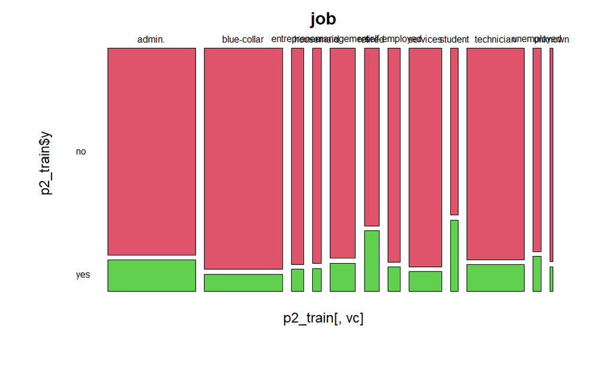

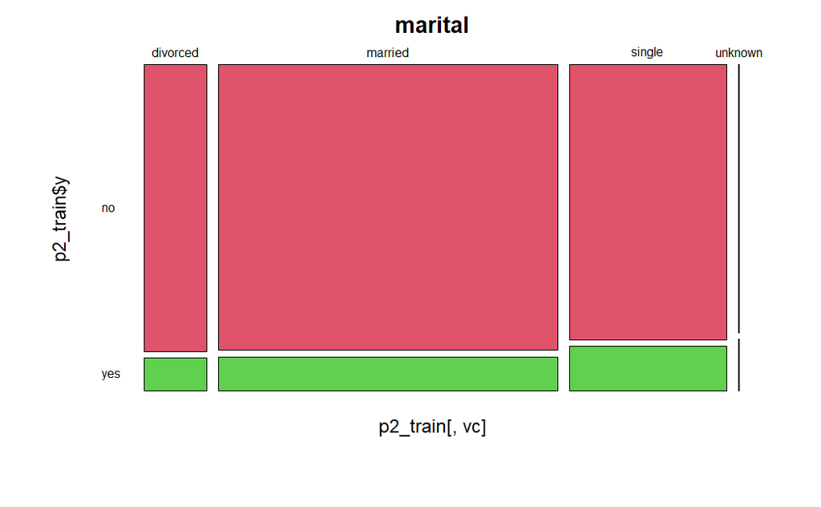

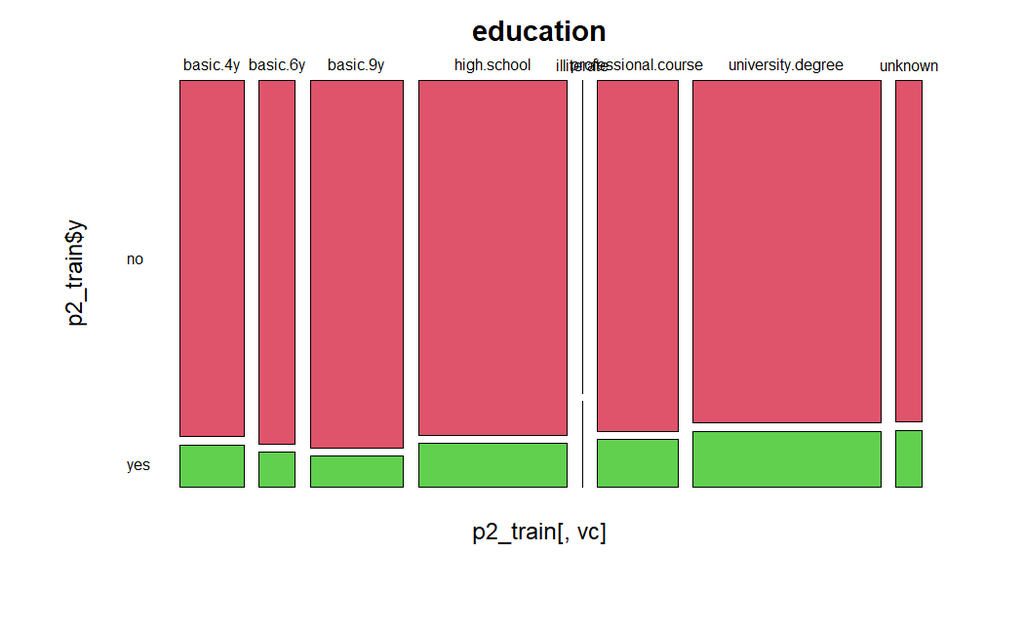

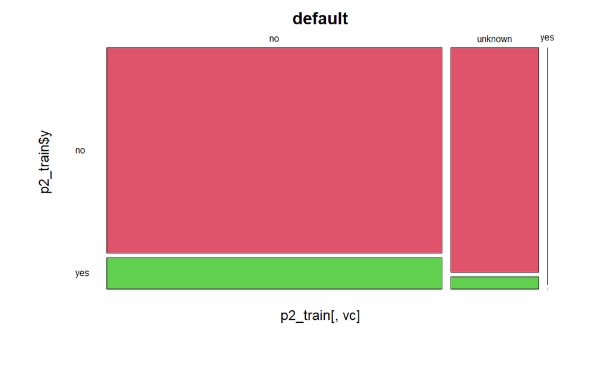

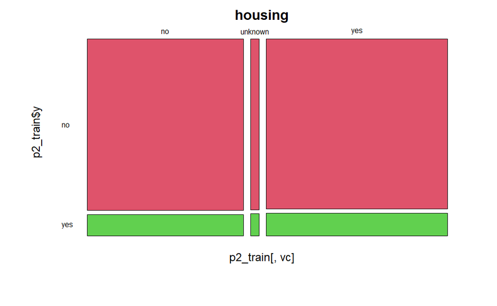

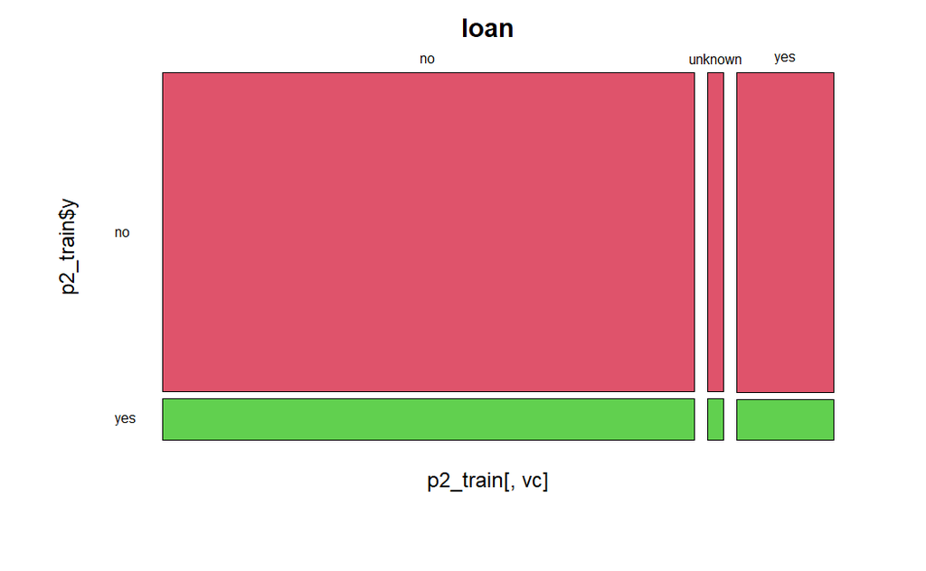

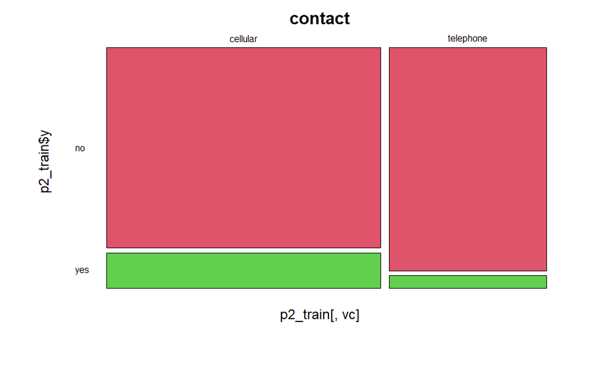

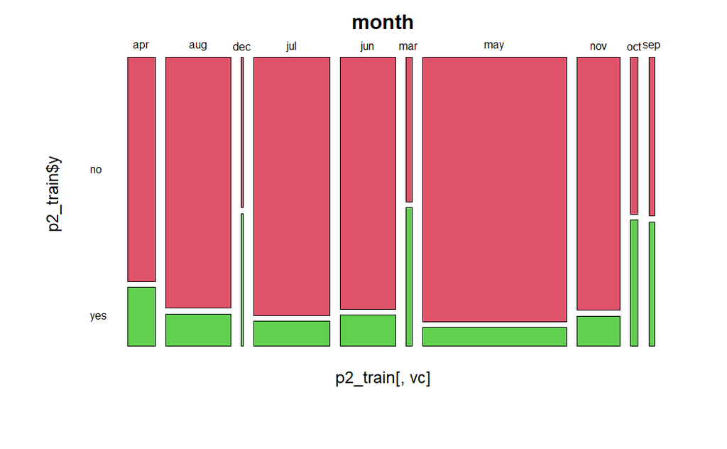

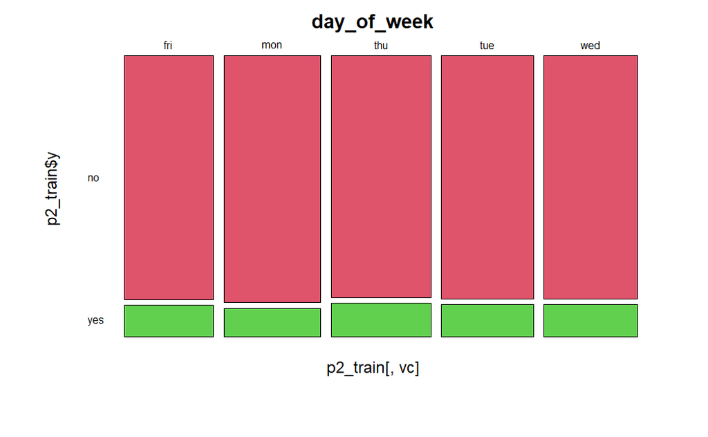

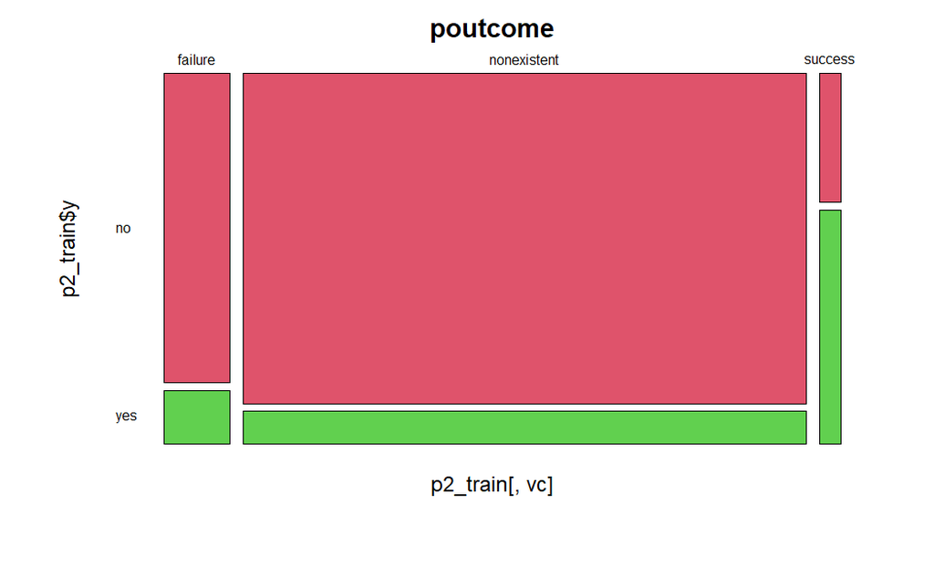

```r
for(vc in var.cat)  mosaicplot(p2_train[,vc]~p2_train$y,main=names(p2_train)[vc],col=2:3,las=1)
```